# Narativno uokvirivanje u hrvatskim katoličkim web medijima: Komparativna analiza (2021.–2024.)

# 2 Podaci i metode

## 2.1 Korpus

Za ovu analizu koristimo podskup koji obuhvaća isključivo web članke (SOURCE_TYPE == “web”). Ovo ograničenje je motivirano dvama razlozima. Prvo, web članci predstavljaju urednički kontrolirani sadržaj koji se može pripisati konkretnom mediju, za razliku od komentara na društvenim mrežama koji odražavaju ponašanje korisnika. Drugo, narativni okviri su smislena analitička kategorija za strukturirane tekstove s naslovima i tijelom teksta, a manje za kratke objave na društvenim mrežama.

```r
n_total <- nrow(full_corpus)
n_sources <- n_distinct(full_corpus$FROM)
n_catholic <- nrow(catholic_corpus)
date_min <- min(full_corpus$DATE)
date_max <- max(full_corpus$DATE)
median_words <- median(full_corpus$word_count, na.rm = TRUE)

summary_tbl <- tibble(
  Obilježje = c(
    "Ukupan broj članaka",
    "Jedinstvenih izvora",
    "Razdoblje",
    "Medijan broja riječi po članku",
    "Članci iz katoličkih medija",
    "Udio katoličkih medija (%)"
  ),
  Vrijednost = c(
    format(n_total, big.mark = ","),
    format(n_sources, big.mark = ","),
    paste(date_min, "do", date_max),
    format(median_words, big.mark = ","),
    format(n_catholic, big.mark = ","),
    round(n_catholic / n_total * 100, 2)
  )
)

kable(summary_tbl, caption = "Tablica 1. Opis korpusa") |>
  kable_styling(bootstrap_options = c("striped", "hover"), full_width = FALSE)
```

Tablica 1. Opis korpusa

| Obilježje | Vrijednost |
| --- | --- |
| Ukupan broj članaka | 443,138 |
| Jedinstvenih izvora | 3,170 |
| Razdoblje | 2021-01-01 do 2026-01-06 |
| Medijan broja riječi po članku | 485 |
| Članci iz katoličkih medija | 92,915 |
| Udio katoličkih medija (%) | 20.97 |

## 2.2 Klasifikacija medija

Medijske izvore klasificiramo u sedam kategorija na temelju vlasničke strukture, uredničke politike i pozicioniranja u hrvatskom medijskom prostoru. Katoličke medije dodatno raščlanjujemo na četiri potkategorije koje odražavaju različite stupnjeve institucionalne povezanosti s Crkvom.

```r
media_dist <- full_corpus |>
  count(media_type, sort = TRUE) |>
  mutate(
    pct = round(n / sum(n) * 100, 2),
    n_sources = sapply(media_type, function(mt) {
      n_distinct(full_corpus$FROM[full_corpus$media_type == mt])
    })
  )

kable(media_dist,
      col.names = c("Tip medija", "Broj članaka", "% korpusa", "Broj izvora")) |>
  kable_styling(bootstrap_options = c("striped", "hover"), full_width = FALSE)
```

Table 1: Tablica 2. Klasifikacija medijskih izvora

| Tip medija | Broj članaka | % korpusa | Broj izvora |
| --- | --- | --- | --- |
| Other | 256216 | 57.82 | 3051 |
| Catholic | 92915 | 20.97 | 72 |
| Liberal | 28160 | 6.35 | 15 |
| Regional | 25415 | 5.74 | 6 |
| Tabloid | 20720 | 4.68 | 12 |
| Conservative | 18516 | 4.18 | 7 |
| Business | 1196 | 0.27 | 7 |

```r
if (nrow(catholic_corpus) > 0) {
  cath_sub_tbl <- catholic_corpus |>
    count(catholic_subcategory, sort = TRUE) |>
    mutate(
      pct = round(n / sum(n) * 100, 2),
      n_sources = sapply(catholic_subcategory, function(cs) {
        n_distinct(catholic_corpus$FROM[catholic_corpus$catholic_subcategory == cs])
      })
    )

  kable(cath_sub_tbl,
        col.names = c("Potkategorija", "Broj članaka", "% katoličkih", "Broj izvora")) |>
    kable_styling(bootstrap_options = c("striped", "hover"), full_width = FALSE)
}
```

Table 2: Tablica 3. Potkategorije katoličkih medija

| Potkategorija | Broj članaka | % katoličkih | Broj izvora |
| --- | --- | --- | --- |
| Official Church | 64391 | 69.30 | 12 |
| Catholic Aligned | 18577 | 19.99 | 5 |
| Catholic Portals | 9943 | 10.70 | 54 |
| Catholic Radio | 4 | 0.00 | 1 |

Razlikovanje između “Official Church” (IKA, Glas Koncila) i “Catholic Aligned” (narod.hr, dnevno.hr, direktno.hr) je analitički ključno. Službeni mediji djeluju pod izravnim uredničkim nadzorom crkvene hijerarhije i njihov sadržaj odražava institucionalnu poziciju Crkve. Katolički orijentirani portali nemaju takvu institucionalnu kontrolu i slobodniji su u odabiru narativnih strategija. Hipoteza je da će se ta razlika manifestirati u različitoj uporabi okvira.

## 2.3 Narativni okviri

Identificiramo osam narativnih okvira metodom rječničke detekcije (dictionary based approach). Za svaki okvir konstruiramo rječnik ključnih riječi i fraza na hrvatskom jeziku. Članak aktivira okvir ako sadrži barem jednu ključnu riječ iz pripadajućeg rječnika. Jedan članak može aktivirati nula, jedan ili više okvira istovremeno.

Okviri su teorijski motivirani literaturom o medijskom uokvirivanju u kontekstu religijskog konzervativizma (Wodak 2015; Haidt 2012) i strukturnim obilježjima dezinformacijskih narativa (Wardle and Derakhshan 2017; Bastos and Tuters 2023).

```r
frame_defs <- tibble(
  Okvir = c(
    "MORAL_DECAY", "FOREIGN_THREAT", "INSTITUTIONAL_DISTRUST",
    "TRADITIONAL_VALUES", "SOVEREIGNTY", "CONSPIRACY",
    "FAITH_DEFENCE", "MEDIA_CRITIQUE"
  ),
  Opis = c(
    "Društvo je u moralnom propadanju. Koristi koncepte dekadencije, grijeha, sekularizacije, nihilizma.",
    "Vanjska sila (EU, globalisti, Soros) nameće svoju volju. Domaći problemi proizlaze iz stranog uplitanja.",
    "Institucije su korumpirane ili manipulativne. Vlada, mediji ili zdravstveni sustav namjerno obmanjuju.",
    "Tradicija, obitelj, vjera i domovina kao temeljne vrijednosti. Afirmativni okvir nasuprot dijagnostičkom.",
    "Nacionalni suverenitet i pravo na samoodređenje. Otpor međunarodnim pritiscima.",
    "Skriveni planovi iza vidljivih događaja. Teorije zavjere o farmaciji, kontroli populacije, globalnim elitama.",
    "Kršćanstvo i Crkva kao žrtva napada, progona ili marginalizacije.",
    "Mainstream mediji su pristrani ili cenzorski. Kontrast s alternativnim izvorima."
  ),
  `Primjeri ključnih riječi` = c(
    "moralni pad, dekadencija, kultura smrti, hedonizam",
    "nametanje, briselski diktat, soros, globalizam, novi svjetski poredak",
    "laž, manipulacija, duboka država, propaganda, korumpirani",
    "tradicija, obitelj, vjera, domovina, crkva, baština",
    "suverenitet, neovisnost, volja naroda, samoodređenje",
    "zavjera, skrivena agenda, big pharma, great reset, čipiranje",
    "kršćanofobija, progon kršćana, napad na crkvu, obrana vjere",
    "mainstream mediji, fake news, pristranost, prešućivanje"
  )
)

kable(frame_defs) |>
  kable_styling(bootstrap_options = c("striped", "hover"), full_width = TRUE) |>
  column_spec(2, width = "30em") |>
  column_spec(3, width = "20em")
```

Table 3: Tablica 4. Definicije narativnih okvira

| Okvir | Opis | Primjeri ključnih riječi |
| --- | --- | --- |
| MORAL_DECAY | Društvo je u moralnom propadanju. Koristi koncepte dekadencije, grijeha, sekularizacije, nihilizma. | moralni pad, dekadencija, kultura smrti, hedonizam |
| FOREIGN_THREAT | Vanjska sila (EU, globalisti, Soros) nameće svoju volju. Domaći problemi proizlaze iz stranog uplitanja. | nametanje, briselski diktat, soros, globalizam, novi svjetski poredak |
| INSTITUTIONAL_DISTRUST | Institucije su korumpirane ili manipulativne. Vlada, mediji ili zdravstveni sustav namjerno obmanjuju. | laž, manipulacija, duboka država, propaganda, korumpirani |
| TRADITIONAL_VALUES | Tradicija, obitelj, vjera i domovina kao temeljne vrijednosti. Afirmativni okvir nasuprot dijagnostičkom. | tradicija, obitelj, vjera, domovina, crkva, baština |
| SOVEREIGNTY | Nacionalni suverenitet i pravo na samoodređenje. Otpor međunarodnim pritiscima. | suverenitet, neovisnost, volja naroda, samoodređenje |
| CONSPIRACY | Skriveni planovi iza vidljivih događaja. Teorije zavjere o farmaciji, kontroli populacije, globalnim elitama. | zavjera, skrivena agenda, big pharma, great reset, čipiranje |
| FAITH_DEFENCE | Kršćanstvo i Crkva kao žrtva napada, progona ili marginalizacije. | kršćanofobija, progon kršćana, napad na crkvu, obrana vjere |
| MEDIA_CRITIQUE | Mainstream mediji su pristrani ili cenzorski. Kontrast s alternativnim izvorima. | mainstream mediji, fake news, pristranost, prešućivanje |

## 2.4 Analitički pristup

Analizu vodimo u četiri koraka. Prvo dajemo deskriptivni pregled distribucije okvira po tipovima medija. Drugo, testiramo statističku značajnost razlika pomoću testova proporcija i hi-kvadrat testova. Treće, koristimo logističku regresiju kako bismo ispitali predviđa li tip medija uporabu specifičnih okvira nakon kontrole za vremensko razdoblje (narativnu fazu) i duljinu teksta. Četvrto, analiziramo supojavljivanje okvira i unutarnju raznolikost katoličkog medijskog prostora.

Svi modeli koriste logističku regresiju oblika:

$$\log\left(\frac{P(\text{frame}_j = 1)}{1 - P(\text{frame}_j = 1)}\right) = \beta_0 + \beta_1 \cdot \text{Catholic} + \beta_2 \cdot \text{phase} + \beta_3 \cdot \log(\text{word\_count})$$

gdje je $\text{frame}_j$ binarni indikator za okvir $j$, $\text{Catholic}$ binarni indikator tipa medija, $\text{phase}$ kategorička varijabla za narativnu fazu, a $\log(\text{word\_count})$ kontrola za duljinu članka (duži članci mehanički imaju veću vjerojatnost aktiviranja ključne riječi).

# 3 Rezultati

## 3.1 Deskriptivna analiza

### 3.1.1 Zastupljenost okvira u punom korpusu

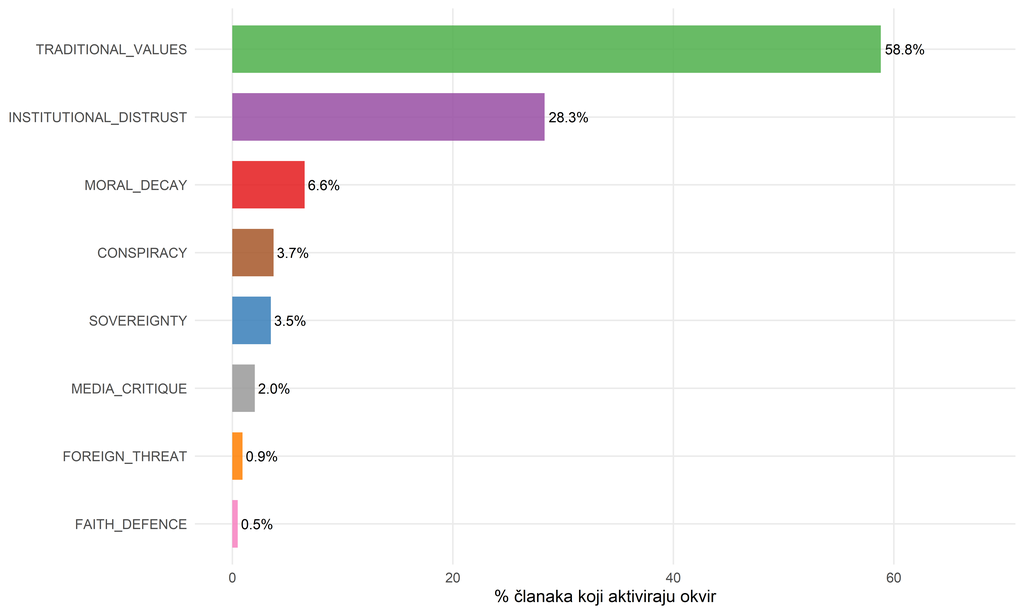

Figure 1: Slika 1. Zastupljenost narativnih okvira u punom korpusu (N = ukupan broj web članaka)

```r
frame_overall <- full_corpus |>
  summarise(across(all_of(frame_cols), ~sum(.x, na.rm = TRUE))) |>
  pivot_longer(everything(), names_to = "frame", values_to = "count") |>
  mutate(
    frame = str_remove(frame, "frame_"),
    pct = count / nrow(full_corpus) * 100
  ) |>
  arrange(desc(count))

ggplot(frame_overall, aes(x = reorder(frame, pct), y = pct, fill = frame)) +
  geom_col(alpha = 0.85, width = 0.7) +
  geom_text(aes(label = sprintf("%.1f%%", pct)), hjust = -0.1, size = 3.5) +
  coord_flip() +
  scale_fill_manual(values = frame_colors, guide = "none") +
  labs(x = NULL, y = "% članaka koji aktiviraju okvir") +
  expand_limits(y = max(frame_overall$pct) * 1.15)
```

```r
kable(frame_overall |>
        mutate(pct = round(pct, 2)) |>
        select(frame, count, pct),
      col.names = c("Okvir", "Broj članaka", "% korpusa"),
      format.args = list(big.mark = ",")) |>
  kable_styling(bootstrap_options = c("striped", "hover"), full_width = FALSE)
```

Table 4: Tablica 5. Zastupljenost okvira u punom korpusu

| Okvir | Broj članaka | % korpusa |
| --- | --- | --- |
| TRADITIONAL_VALUES | 260,648 | 58.82 |
| INSTITUTIONAL_DISTRUST | 125,551 | 28.33 |
| MORAL_DECAY | 29,077 | 6.56 |
| CONSPIRACY | 16,606 | 3.75 |
| SOVEREIGNTY | 15,503 | 3.50 |
| MEDIA_CRITIQUE | 9,075 | 2.05 |
| FOREIGN_THREAT | 4,127 | 0.93 |
| FAITH_DEFENCE | 2,197 | 0.50 |

### 3.1.2 Okviri po tipu medija (IP1)

Središnje pitanje ovog rada jest razlikuju li se katolički mediji od ostalih u uporabi narativnih okvira. Sljedeća toplinska karta prikazuje postotak članaka koji aktiviraju svaki okvir, raščlanjen po tipu medija. Svaka ćelija odgovara na pitanje: od svih članaka tog tipa medija, koliki postotak sadrži ključne riječi za taj okvir?

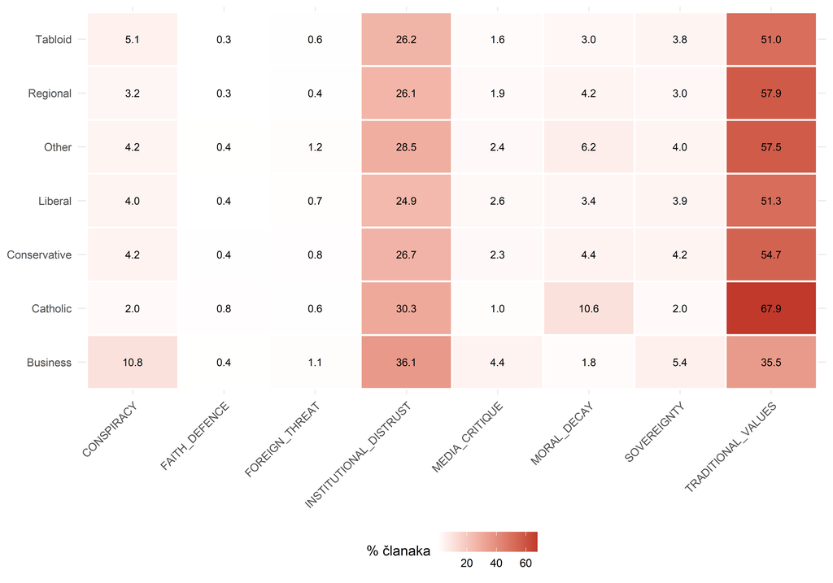

Figure 2: Slika 2. Zastupljenost okvira po tipu medija (% članaka)

```r
frame_by_media <- full_corpus |>
  group_by(media_type) |>
  summarise(
    n = n(),
    across(all_of(frame_cols), ~sum(.x, na.rm = TRUE) / n() * 100),
    .groups = "drop"
  ) |>
  filter(n >= 50) |>
  pivot_longer(cols = all_of(frame_cols), names_to = "frame", values_to = "pct") |>
  mutate(frame = str_remove(frame, "frame_"))

ggplot(frame_by_media, aes(x = frame, y = media_type, fill = pct)) +
  geom_tile(color = "white", linewidth = 0.8) +
  geom_text(aes(label = sprintf("%.1f", pct)), size = 3.2) +
  scale_fill_gradient(low = "white", high = "#c0392b", name = "% članaka") +
  labs(x = NULL, y = NULL) +
  theme(axis.text.x = element_text(angle = 45, hjust = 1))
```

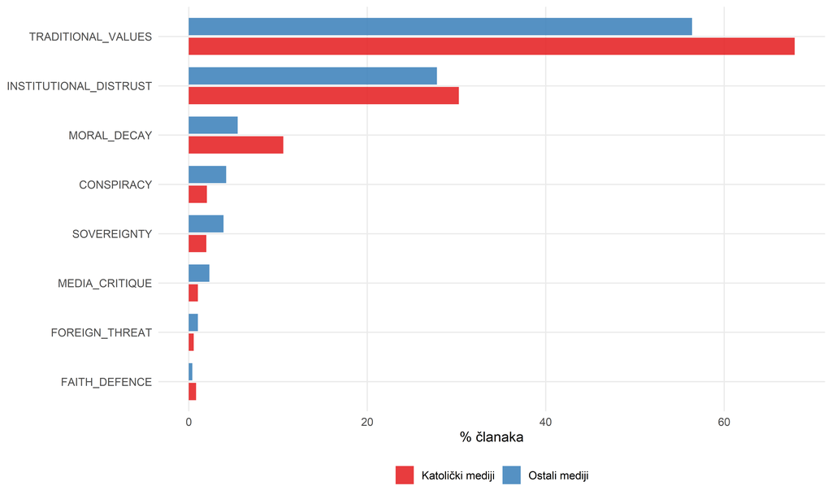

Figure 3: Slika 3. Komparativni profil okvira: katolički mediji vs. svi ostali

```r
comparison <- full_corpus |>
  mutate(group = ifelse(media_type == "Catholic", "Katolički mediji", "Ostali mediji")) |>
  group_by(group) |>
  summarise(
    n = n(),
    across(all_of(frame_cols), ~sum(.x, na.rm = TRUE) / n() * 100),
    .groups = "drop"
  ) |>
  pivot_longer(cols = all_of(frame_cols), names_to = "frame", values_to = "pct") |>
  mutate(frame = str_remove(frame, "frame_"))

ggplot(comparison, aes(x = reorder(frame, pct), y = pct, fill = group)) +
  geom_col(position = position_dodge(width = 0.8), alpha = 0.85, width = 0.7) +
  coord_flip() +
  scale_fill_manual(values = c("Katolički mediji" = "#e41a1c", "Ostali mediji" = "#377eb8")) +
  labs(x = NULL, y = "% članaka", fill = NULL)
```

### 3.1.3 Testovi proporcija

Za svaki okvir testiramo razlikuje li se udio članaka s okvirom u katoličkim medijima od udjela u svim ostalim medijima. Koristimo dvostrani test proporcija (prop.test) koji je robustan za velike uzorke.

```r
prop_results <- lapply(frame_cols, function(fc) {
  fname <- str_remove(fc, "frame_")
  cath <- full_corpus |> filter(media_type == "Catholic")
  other <- full_corpus |> filter(media_type != "Catholic")

  x <- c(sum(cath[[fc]], na.rm = TRUE), sum(other[[fc]], na.rm = TRUE))
  n <- c(nrow(cath), nrow(other))

  test <- prop.test(x, n)

  tibble(
    frame = fname,
    pct_catholic = round(x[1] / n[1] * 100, 2),
    pct_other = round(x[2] / n[2] * 100, 2),
    diff = round(x[1] / n[1] * 100 - x[2] / n[2] * 100, 2),
    chi_sq = round(test$statistic, 1),
    p_value = test$p.value,
    p_display = ifelse(test$p.value < 0.001, "< 0.001", sprintf("%.3f", test$p.value))
  )
}) |>
  bind_rows() |>
  arrange(desc(abs(diff)))

kable(prop_results |> select(frame, pct_catholic, pct_other, diff, chi_sq, p_display),
      col.names = c("Okvir", "% katolički", "% ostali", "Razlika (pp)",
                     "Chi-sq", "p")) |>
  kable_styling(bootstrap_options = c("striped", "hover"), full_width = FALSE)
```

Table 5: Tablica 6. Testovi razlike proporcija: katolički vs. ostali mediji

| Okvir | % katolički | % ostali | Razlika (pp) | Chi-sq | p |
| --- | --- | --- | --- | --- | --- |
| TRADITIONAL_VALUES | 67.91 | 56.41 | 11.50 | 4006.8 | < 0.001 |
| MORAL_DECAY | 10.60 | 5.49 | 5.10 | 3119.8 | < 0.001 |
| INSTITUTIONAL_DISTRUST | 30.27 | 27.82 | 2.45 | 217.2 | < 0.001 |
| CONSPIRACY | 2.04 | 4.20 | -2.17 | 954.9 | < 0.001 |
| SOVEREIGNTY | 1.99 | 3.90 | -1.91 | 796.4 | < 0.001 |
| MEDIA_CRITIQUE | 1.04 | 2.32 | -1.28 | 599.0 | < 0.001 |
| FOREIGN_THREAT | 0.56 | 1.03 | -0.47 | 173.5 | < 0.001 |
| FAITH_DEFENCE | 0.83 | 0.41 | 0.42 | 261.6 | < 0.001 |

Razlika u postotnim bodovima (pp) pokazuje za koliko se katolički mediji razlikuju od ostalih u apsolutnom smislu. Pozitivna razlika znači da katolički mediji češće koriste taj okvir. Negativna razlika znači da ga koriste rjeđe.

## 3.2 Logistička regresija (IP1)

Deskriptivne razlike mogu biti artefakt drugih faktora. Duži članci mehanički imaju veću vjerojatnost da sadrže ključnu riječ. Različita vremenska razdoblja (npr. pandemija) proizvode različite tematske fokuse. Logistička regresija omogućuje nam da izdvojimo efekt tipa medija nakon kontrole za ove kovarijate.

Za svaki okvir procjenjujemo model u kojem je zavisna varijabla binarna (okvir prisutan ili ne), a prediktorske varijable su tip medija (Catholic vs. referentna kategorija Other), narativna faza i logaritam broja riječi. Logaritam koristimo jer je distribucija duljine članaka izrazito desno asimetrična.

```r
# Prepare data for regression
reg_data <- full_corpus |>
  mutate(
    is_catholic = ifelse(media_type == "Catholic", 1L, 0L),
    log_words = log(pmax(word_count, 1)),
    media_fct = relevel(factor(media_type), ref = "Other"),
    phase_fct = factor(narrative_phase)
  ) |>
  filter(!is.na(narrative_phase))

# Fit logistic regression for each frame: frame ~ media_type + phase + log_words
model_results <- lapply(frame_cols, function(fc) {
  fname <- str_remove(fc, "frame_")

  formula <- as.formula(paste0(fc, " ~ media_fct + phase_fct + log_words"))

  fit <- glm(formula, data = reg_data, family = binomial(link = "logit"))

  tidy_fit <- tidy(fit, conf.int = TRUE, exponentiate = TRUE) |>
    filter(str_detect(term, "media_fct")) |>
    mutate(
      frame = fname,
      term = str_remove(term, "media_fct"),
      across(c(estimate, conf.low, conf.high), ~round(.x, 3)),
      p.value = ifelse(p.value < 0.001, "< 0.001", sprintf("%.3f", p.value))
    ) |>
    select(frame, term, estimate, conf.low, conf.high, p.value)

  tidy_fit
}) |>
  bind_rows()
```

```r
# Show Catholic coefficients for all frames
catholic_coefs <- model_results |>
  filter(term == "Catholic") |>
  arrange(desc(estimate))

kable(catholic_coefs,
      col.names = c("Okvir", "Medij", "OR", "95% CI donji", "95% CI gornji", "p")) |>
  kable_styling(bootstrap_options = c("striped", "hover"), full_width = FALSE)
```

Table 6: Tablica 7. Logistička regresija: Odds ratios za tip medija (referentna kategorija: Other)

| Okvir | Medij | OR | 95% CI donji | 95% CI gornji | p |
| --- | --- | --- | --- | --- | --- |
| FAITH_DEFENCE | Catholic | 2.222 | 2.020 | 2.443 | < 0.001 |
| MORAL_DECAY | Catholic | 2.117 | 2.058 | 2.177 | < 0.001 |
| TRADITIONAL_VALUES | Catholic | 1.675 | 1.647 | 1.703 | < 0.001 |
| INSTITUTIONAL_DISTRUST | Catholic | 1.305 | 1.282 | 1.329 | < 0.001 |
| FOREIGN_THREAT | Catholic | 0.740 | 0.671 | 0.814 | < 0.001 |
| MEDIA_CRITIQUE | Catholic | 0.689 | 0.642 | 0.739 | < 0.001 |
| SOVEREIGNTY | Catholic | 0.671 | 0.637 | 0.707 | < 0.001 |
| CONSPIRACY | Catholic | 0.630 | 0.598 | 0.662 | < 0.001 |

Rezultati su prikazani kao odds ratios (OR). OR iznad 1 znači da katolički mediji imaju veće izglede za aktiviranje tog okvira u usporedbi s referentnom kategorijom (Other), nakon kontrole za vremensko razdoblje i duljinu članka. OR ispod 1 znači manje izglede.

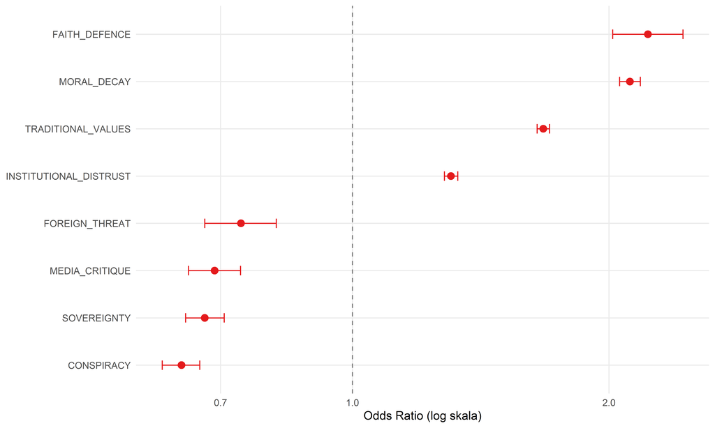

```r
ggplot(catholic_coefs, aes(x = reorder(frame, estimate), y = estimate)) +
  geom_point(size = 3, color = "#e41a1c") +
  geom_errorbar(aes(ymin = conf.low, ymax = conf.high), width = 0.2, color = "#e41a1c") +
  geom_hline(yintercept = 1, linetype = "dashed", color = "gray50") +
  coord_flip() +
  scale_y_log10() +
  labs(
    x = NULL,
    y = "Odds Ratio (log skala)"
  )
```

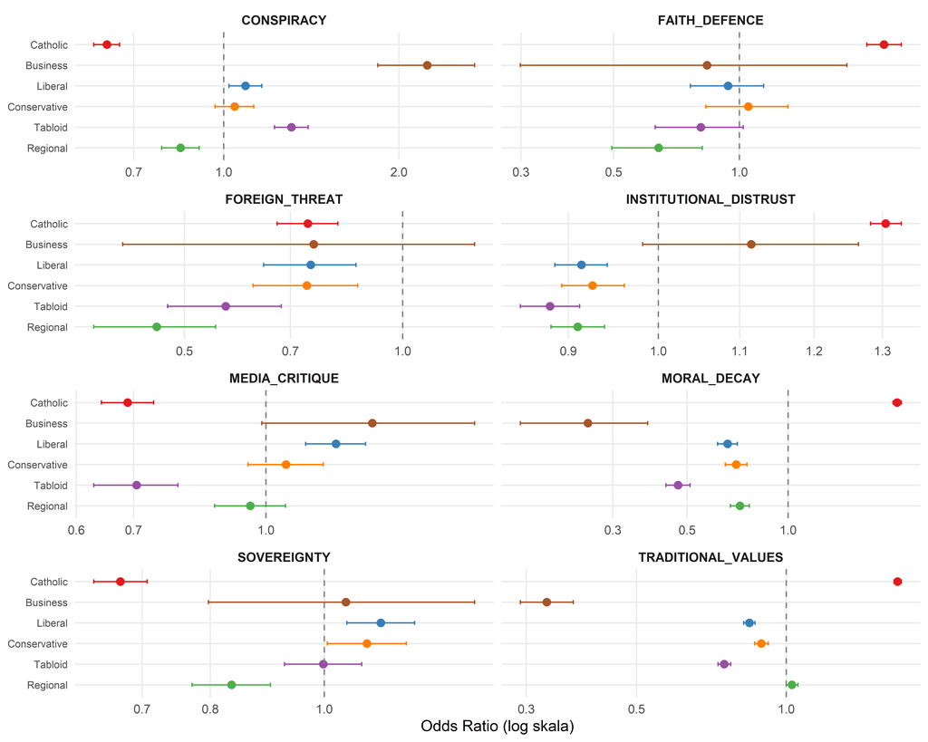

Figure 5: Slika 5. Odds ratios za sve tipove medija u usporedbi s kategorijom Other

```r
ggplot(model_results, aes(x = reorder(term, estimate), y = estimate, color = term)) +
  geom_point(size = 2.5) +
  geom_errorbar(aes(ymin = conf.low, ymax = conf.high), width = 0.2) +
  geom_hline(yintercept = 1, linetype = "dashed", color = "gray50") +
  coord_flip() +
  scale_y_log10() +
  facet_wrap(~frame, ncol = 2, scales = "free_x") +
  scale_color_manual(values = media_colors, guide = "none") +
  labs(
    x = NULL,
    y = "Odds Ratio (log skala)"
  ) +
  theme(axis.text.y = element_text(size = 8))
```

Slika 5 prikazuje potpuni komparativni pregled. Svaki panel odgovara jednom okviru, a svaka točka jednom tipu medija u usporedbi s kategorijom Other. Ovaj prikaz omogućuje čitatelju da vidi ne samo kako se katolički mediji razlikuju nego i kako se njihov položaj odnosi prema ostalim kategorijama.

## 3.3 Narativni paketi: supojavljivanje okvira (IP2)

Gamson and Modigliani (1989) pokazuju da se medijski okviri rijetko pojavljuju izolirano. Umjesto toga, mediji konstruiraju “interpretativne pakete” koji povezuju više okvira u koherentnu narativnu strukturu. Da bismo identificirali takve pakete, analiziramo matricu supojavljivanja okvira i uspoređujemo njenu strukturu između katoličkih i ostalih medija.

Matrica prikazuje uvjetnu vjerojatnost P(stupac | redak), to jest kolika je vjerojatnost da članak koji sadrži okvir iz retka također sadrži okvir iz stupca.

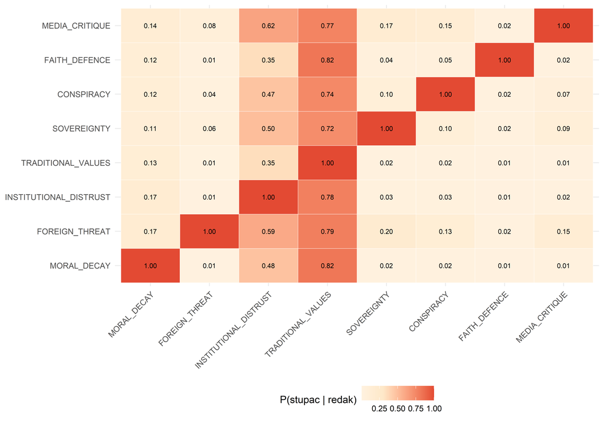

Figure 6: Slika 6. Matrica supojavljivanja okvira u katoličkim medijima

```r
build_cooccurrence <- function(data, label) {
  mat <- data |> select(all_of(frame_cols)) |> as.matrix()
  colnames(mat) <- str_remove(colnames(mat), "frame_")
  co <- crossprod(mat)
  diag_vals <- diag(co)
  cond <- sweep(co, 1, pmax(diag_vals, 1), "/")
  df <- as.data.frame(as.table(cond))
  names(df) <- c("row_frame", "col_frame", "prob")
  df$source <- label
  df
}

co_catholic <- build_cooccurrence(catholic_corpus, "Katolički")
co_other <- build_cooccurrence(full_corpus |> filter(media_type != "Catholic"), "Ostali")

ggplot(co_catholic, aes(x = col_frame, y = row_frame, fill = prob)) +
  geom_tile(color = "white") +
  geom_text(aes(label = sprintf("%.2f", prob)), size = 2.8) +
  scale_fill_gradient2(low = "white", mid = "#fee8c8", high = "#e34a33",
                       midpoint = 0.3, name = "P(stupac | redak)") +
  labs(x = NULL, y = NULL) +
  theme(axis.text.x = element_text(angle = 45, hjust = 1))
```

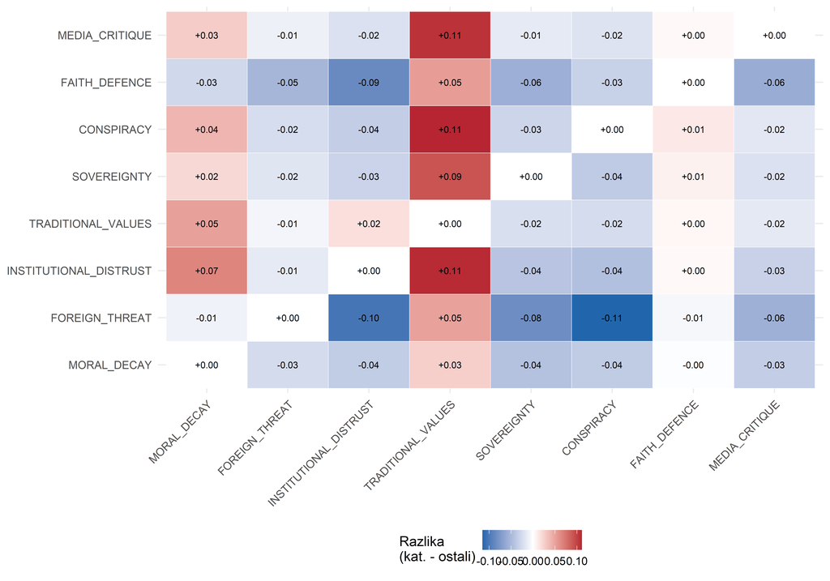

Figure 7: Slika 7. Razlika u supojavljivanju okvira: katolički minus ostali mediji. Pozitivne vrijednosti (crveno) znače da je supojavljivanje jače u katoličkim medijima.

```r
co_diff <- co_catholic |>
  inner_join(co_other, by = c("row_frame", "col_frame"), suffix = c("_cath", "_other")) |>
  mutate(diff = prob_cath - prob_other)

ggplot(co_diff, aes(x = col_frame, y = row_frame, fill = diff)) +
  geom_tile(color = "white") +
  geom_text(aes(label = sprintf("%+.2f", diff)), size = 2.8) +
  scale_fill_gradient2(low = "#2166ac", mid = "white", high = "#b2182b",
                       midpoint = 0, name = "Razlika\n(kat. - ostali)") +
  labs(x = NULL, y = NULL) +
  theme(axis.text.x = element_text(angle = 45, hjust = 1))
```

Razlika u supojavljivanju otkriva narativne pakete specifične za katoličke medije. Pozitivne vrijednosti (crveno) ukazuju na kombinacije okvira koje su izrazitije u katoličkim medijima. Na primjer, ako je veza između CONSPIRACY i INSTITUTIONAL_DISTRUST snažnija u katoličkim medijima, to sugerira da ti mediji češće konstruiraju narativ u kojem se institucionalno nepovjerenje artikulira kroz konspirativni okvir.

### 3.3.1 Prosječan broj okvira po članku

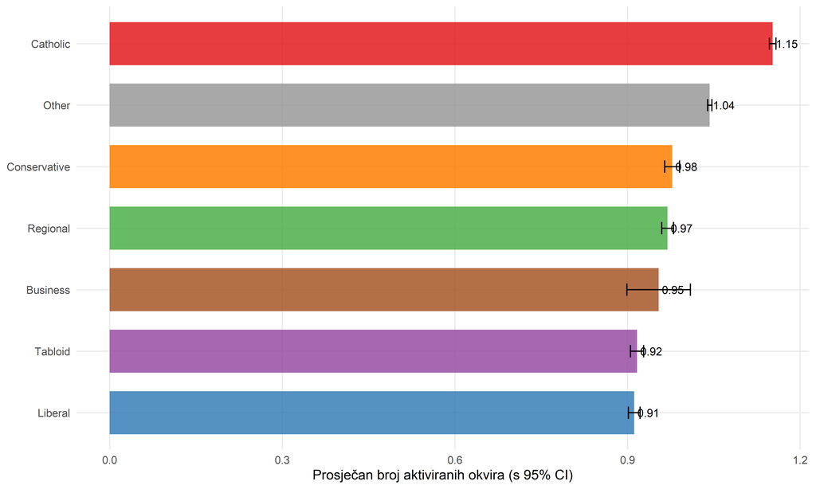

Figure 8: Slika 8. Prosječan broj istovremeno aktiviranih okvira po tipu medija

```r
nframes_summary <- full_corpus |>
  group_by(media_type) |>
  summarise(
    mean_frames = mean(n_frames, na.rm = TRUE),
    se = sd(n_frames, na.rm = TRUE) / sqrt(n()),
    .groups = "drop"
  )

ggplot(nframes_summary, aes(x = reorder(media_type, mean_frames), y = mean_frames,
                            fill = media_type)) +
  geom_col(alpha = 0.85, width = 0.7) +
  geom_errorbar(aes(ymin = mean_frames - 1.96 * se, ymax = mean_frames + 1.96 * se),
                width = 0.2) +
  geom_text(aes(label = sprintf("%.2f", mean_frames)), hjust = -0.15, size = 3.5) +
  coord_flip() +
  scale_fill_manual(values = media_colors, guide = "none") +
  labs(x = NULL, y = "Prosječan broj aktiviranih okvira (s 95% CI)")
```

Prosječan broj istovremeno aktiviranih okvira indikator je narativne složenosti. Viša vrijednost sugerira da medij češće kombinira više interpretativnih perspektiva u jednom članku.

## 3.4 Unutarnja raznolikost katoličkog medijskog prostora (IP3)

### 3.4.1 Usporedba potkategorija

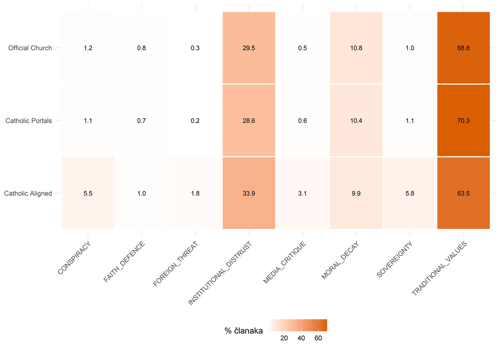

Figure 9: Slika 9. Narativni profili katoličkih potkategorija

```r
if (n_distinct(catholic_corpus$catholic_subcategory) > 1) {
  frame_cath_sub <- catholic_corpus |>
    group_by(catholic_subcategory) |>
    summarise(
      n = n(),
      across(all_of(frame_cols), ~sum(.x, na.rm = TRUE) / n() * 100),
      .groups = "drop"
    ) |>
    filter(n >= 20) |>
    pivot_longer(cols = all_of(frame_cols), names_to = "frame", values_to = "pct") |>
    mutate(frame = str_remove(frame, "frame_"))

  ggplot(frame_cath_sub, aes(x = frame, y = catholic_subcategory, fill = pct)) +
    geom_tile(color = "white", linewidth = 0.8) +
    geom_text(aes(label = sprintf("%.1f", pct)), size = 3.2) +
    scale_fill_gradient(low = "white", high = "#d95f02", name = "% članaka") +
    labs(x = NULL, y = NULL) +
    theme(axis.text.x = element_text(angle = 45, hjust = 1))
}
```

### 3.4.2 Logistička regresija unutar katoličkih medija

```r
if (n_distinct(catholic_corpus$catholic_subcategory) > 1) {
  cath_reg_data <- catholic_corpus |>
    mutate(
      sub_fct = relevel(factor(catholic_subcategory), ref = "Official Church"),
      log_words = log(pmax(word_count, 1)),
      phase_fct = factor(narrative_phase)
    ) |>
    filter(!is.na(narrative_phase))

  cath_model_results <- lapply(frame_cols, function(fc) {
    fname <- str_remove(fc, "frame_")

    # Check if there's enough variance
    if (sum(cath_reg_data[[fc]], na.rm = TRUE) < 10) return(NULL)

    formula <- as.formula(paste0(fc, " ~ sub_fct + phase_fct + log_words"))

    fit <- tryCatch(
      glm(formula, data = cath_reg_data, family = binomial(link = "logit")),
      error = function(e) NULL
    )
    if (is.null(fit)) return(NULL)

    tidy(fit, conf.int = TRUE, exponentiate = TRUE) |>
      filter(str_detect(term, "sub_fct")) |>
      mutate(
        frame = fname,
        term = str_remove(term, "sub_fct"),
        across(c(estimate, conf.low, conf.high), ~round(.x, 3)),
        p.value = ifelse(p.value < 0.001, "< 0.001", sprintf("%.3f", p.value))
      ) |>
      select(frame, term, estimate, conf.low, conf.high, p.value)
  }) |>
    bind_rows()

  if (nrow(cath_model_results) > 0) {
    # Show Catholic Aligned results (key comparison)
    aligned_coefs <- cath_model_results |>
      filter(term == "Catholic Aligned") |>
      arrange(desc(estimate))

    kable(aligned_coefs,
          col.names = c("Okvir", "Potkategorija", "OR", "CI donji", "CI gornji", "p")) |>
      kable_styling(bootstrap_options = c("striped", "hover"), full_width = FALSE)
  }
}
```

Table 7: Tablica 8. Odds ratios za katoličke potkategorije (referentna kategorija: Official Church)

| Okvir | Potkategorija | OR | CI donji | CI gornji | p |
| --- | --- | --- | --- | --- | --- |
| SOVEREIGNTY | Catholic Aligned | 4.567 | 4.123 | 5.062 | < 0.001 |
| FOREIGN_THREAT | Catholic Aligned | 4.254 | 3.520 | 5.157 | < 0.001 |
| MEDIA_CRITIQUE | Catholic Aligned | 3.978 | 3.453 | 4.588 | < 0.001 |
| CONSPIRACY | Catholic Aligned | 3.572 | 3.236 | 3.943 | < 0.001 |
| INSTITUTIONAL_DISTRUST | Catholic Aligned | 0.996 | 0.959 | 1.034 | 0.818 |
| FAITH_DEFENCE | Catholic Aligned | 0.992 | 0.833 | 1.177 | 0.930 |
| MORAL_DECAY | Catholic Aligned | 0.675 | 0.637 | 0.716 | < 0.001 |
| TRADITIONAL_VALUES | Catholic Aligned | 0.577 | 0.556 | 0.599 | < 0.001 |

Ovaj model uspoređuje katolički orijentirane portale (Catholic Aligned) sa službenim crkvenim medijima (Official Church) kao referentnom kategorijom. OR iznad 1 znači da Catholic Aligned portali češće koriste taj okvir nego službeni mediji, uz iste uvjete.

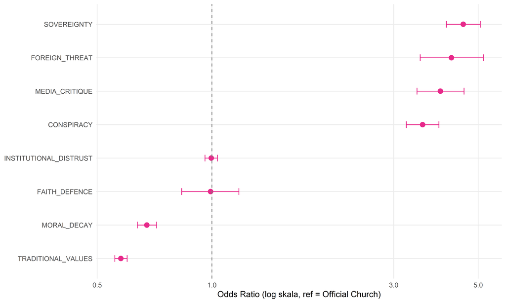

Figure 10: Slika 10. Odds ratios za Catholic Aligned vs. Official Church po okviru

```r
if (exists("aligned_coefs") && nrow(aligned_coefs) > 0) {
  ggplot(aligned_coefs, aes(x = reorder(frame, estimate), y = estimate)) +
    geom_point(size = 3, color = "#e7298a") +
    geom_errorbar(aes(ymin = conf.low, ymax = conf.high), width = 0.2, color = "#e7298a") +
    geom_hline(yintercept = 1, linetype = "dashed", color = "gray50") +
    coord_flip() +
    scale_y_log10() +
    labs(
      x = NULL,
      y = "Odds Ratio (log skala, ref = Official Church)"
    )
}
```

## 3.5 Vremenska dinamika

### 3.5.1 Evolucija okvira u katoličkim medijima

```r
if (nrow(catholic_corpus) > 0) {
  frame_ts_cath <- catholic_corpus |>
    group_by(year_month) |>
    summarise(
      n_total = n(),
      across(all_of(frame_cols), ~sum(.x, na.rm = TRUE)),
      .groups = "drop"
    ) |>
    pivot_longer(cols = all_of(frame_cols), names_to = "frame", values_to = "count") |>
    mutate(
      frame = str_remove(frame, "frame_"),
      pct = count / n_total * 100
    ) |>
    filter(!is.na(year_month))

  ggplot(frame_ts_cath, aes(x = year_month, y = pct, color = frame)) +
    geom_line(linewidth = 0.5, alpha = 0.5) +
    geom_smooth(method = "loess", se = FALSE, linewidth = 1.2, span = 0.3) +
    facet_wrap(~frame, ncol = 2, scales = "free_y") +
    scale_color_manual(values = frame_colors, guide = "none") +
    scale_x_date(date_breaks = "6 months", date_labels = "%b\n%Y") +
    labs(x = NULL, y = "% članaka") +
    theme(axis.text.x = element_text(size = 8))
}
```

[figure not shown]

Figure 11: Slika 11. Evolucija okvira u katoličkim medijima kroz vrijeme

### 3.5.2 Okviri po narativnoj fazi

```r
if (nrow(catholic_corpus) > 0) {
  phase_tbl <- catholic_corpus |>
    filter(!is.na(narrative_phase)) |>
    group_by(narrative_phase) |>
    summarise(
      N = n(),
      TRADITIONAL = round(sum(frame_TRADITIONAL_VALUES, na.rm = TRUE) / n() * 100, 1),
      CONSPIRACY = round(sum(frame_CONSPIRACY, na.rm = TRUE) / n() * 100, 1),
      DISTRUST = round(sum(frame_INSTITUTIONAL_DISTRUST, na.rm = TRUE) / n() * 100, 1),
      FOREIGN = round(sum(frame_FOREIGN_THREAT, na.rm = TRUE) / n() * 100, 1),
      FAITH = round(sum(frame_FAITH_DEFENCE, na.rm = TRUE) / n() * 100, 1),
      avg_frames = round(mean(n_frames, na.rm = TRUE), 2),
      .groups = "drop"
    )

  kable(phase_tbl,
        col.names = c("Faza", "N", "% trad. vrij.", "% zavjera",
                       "% nepovjerenje", "% vanjska prij.",
                       "% obrana vjere", "Prosj. okvira")) |>
    kable_styling(bootstrap_options = c("striped", "hover"), full_width = FALSE)
}
```

Table 8: Tablica 9. Zastupljenost ključnih okvira po narativnoj fazi u katoličkim medijima

| Faza | N | % trad. vrij. | % zavjera | % nepovjerenje | % vanjska prij. | % obrana vjere | Prosj. okvira |
| --- | --- | --- | --- | --- | --- | --- | --- |
| COVID Peak (early 2021) | 9783 | 68.4 | 1.9 | 32.0 | 0.7 | 0.6 | 1.19 |
| Post-Vaccine Debate | 13275 | 70.1 | 2.3 | 33.2 | 0.6 | 0.8 | 1.21 |
| Ukraine and Energy Crisis | 11590 | 68.9 | 1.7 | 30.9 | 0.3 | 0.7 | 1.18 |
| Euro Adoption | 5665 | 69.8 | 1.4 | 28.4 | 0.3 | 0.7 | 1.14 |
| Culture Wars Period | 18274 | 72.6 | 1.6 | 31.9 | 0.4 | 0.9 | 1.21 |
| Election Run-up 2024 | 34328 | 63.8 | 2.4 | 27.9 | 0.7 | 0.9 | 1.08 |

## 3.6 Analiza aktera: tko govori unutar kojih okvira

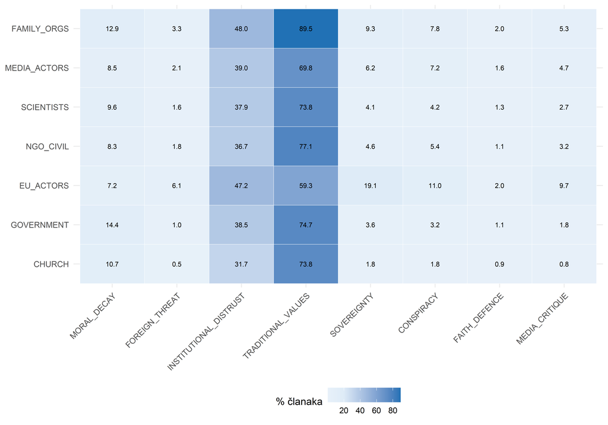

Figure 12: Slika 12. Asocijacija aktera i okvira u katoličkim medijima. Vrijednosti pokazuju postotak članaka s akterom koji istovremeno aktiviraju okvir.

```r
if (nrow(catholic_corpus) > 0) {
  a_mat <- catholic_corpus |> select(all_of(actor_cols)) |> as.matrix()
  f_mat <- catholic_corpus |> select(all_of(frame_cols)) |> as.matrix()

  af_cross <- t(a_mat) %*% f_mat
  af_pct <- sweep(af_cross, 1, pmax(colSums(a_mat), 1), "/") * 100

  colnames(af_pct) <- str_remove(colnames(af_pct), "frame_")
  rownames(af_pct) <- str_remove(rownames(af_pct), "actor_")

  af_df <- as.data.frame(as.table(af_pct))
  names(af_df) <- c("actor", "frame", "pct")

  ggplot(af_df, aes(x = frame, y = actor, fill = pct)) +
    geom_tile(color = "white") +
    geom_text(aes(label = sprintf("%.1f", pct)), size = 2.8) +
    scale_fill_gradient2(low = "white", mid = "#deebf7", high = "#2171b5",
                         midpoint = 20, name = "% članaka") +
    labs(x = NULL, y = NULL) +
    theme(axis.text.x = element_text(angle = 45, hjust = 1))
}
```